# QB Prospect Model

The basis of this model is to predict NFL efficiency for quarterback prospects. I am measuring efficiency using a metric I devised called TANY/A*. A few others before me have found similar metrics, but I haven't seen any predictive studies on them.

ANY/A (Adjusted Net Yards per Attempt), which measures passing yards per attempt while accounting for sacks, touchdowns, and interceptions. It is a well-regarded QB efficiency metric, since it accounts for all aspects of passing. The simple Yards per Attempt (Y/A) is a bit more stable year-to-year, so some prefer that. But when adding significantly more context, only a minor drop in stability is palatable in my opinion. In fact, Chase Stuart showed than ANY/A correlates with wins better than any other efficiency metric, as shown here: http://www.footballperspective.com/correlating-passing-stats-with-wins/.

Also see https://www.pro-football-reference.com/about/glossary.htm for definitions of these metrics.

TANY/A takes it a couple steps further and factors in rushing stats as well to get a comprehensive measure of a quarterback's per-play efficiency. It is a bit more stable than ANY/A. It still trails Y/A in that regard, but again I find that impressive considering the added context. Given the high variance of competition level in college football, I adjusted for schedule & era to get TANY/A*. At the NFL level, this can often mean a lot of work for little gain. However, it improved the predictiveness of my metric by up to 30%, depending on the specific test.

Using college efficiency to predict draft capital, the popular metrics have an R^2 anywhere from .107 to .125. TANY/A has a R^2 of .141, while the schedule/era-adjusted TANY/A* bumps that up to .180. That's anywhere from 40% to 70% better than the traditional metrics. These correlations may seem low to get excited about. However, the random nature of football (short seasons & 22 players interacting at once) means the threshold is much lower than other sports, especially baseball. When looking at the player level, an R^2 above .30 means the metric can be used on its own to predict, while anything above .10 is good enough to be a prominent feature in a model.

My goal with this model is to produce predicted NFL TANY/A*, which can be used as the primary metric in evaluating quarterback prospects. Besides college efficiency (using the same metric), height, age, and draft capital spent on the QB are the variables I've found to be significant. (Note: Draft Capital is my log-based conversion of draft position, similar to the draft pick value charts which NFL teams utilize).

Below, I show how my model performs versus draft capital, essentially finding out if I can beat the NFL as a whole in evaluating QB prospects. At the bottom is a chart visualizing the results with accompanying analysis. Everything in between is the modeling & testing itself.

```python
# Import dependencies
%matplotlib inline
import matplotlib.pyplot as plt
import pandas as pd
import numpy as np
import random
```

## Prepare Data

```python
# Read in historical data (All FBS QBs drafted from 2000-2016)
data = pd.read_csv('2000-2016_FBS_QBs.csv')
data = data.drop("college_AY/A", axis=1)
data.head()
```

|  | height | rookie_age | college_TANY/A* | draft_capital | nfl_opps | nfl_TANY/A* |
| --- | --- | --- | --- | --- | --- | --- |
| 0 | 74 | 21.9 | 9.83 | 222.2 | 1560 | 5.72 |
| 1 | 77 | 22.4 | 9.64 | 2.4 | 444 | 2.97 |
| 2 | 77 | 23.3 | 9.31 | 148.4 | 728 | 4.61 |
| 3 | 75 | 23.0 | 8.96 | 69.4 | 60 | 0.17 |
| 4 | 76 | 23.0 | 8.84 | 254.0 | 3381 | 5.73 |

```python
# Filter dataset to QBs with a full season or more of career attempts
    # This will be used when measuring efficiency
filtered = data[data['nfl_opps'] >= 500]
filtered.head()
```

|  | height | rookie_age | college_TANY/A* | draft_capital | nfl_opps | nfl_TANY/A* |
| --- | --- | --- | --- | --- | --- | --- |
| 0 | 74 | 21.9 | 9.83 | 222.2 | 1560 | 5.72 |
| 2 | 77 | 23.3 | 9.31 | 148.4 | 728 | 4.61 |
| 4 | 76 | 23.0 | 8.84 | 254.0 | 3381 | 5.73 |
| 8 | 77 | 23.6 | 8.40 | 164.7 | 1878 | 5.21 |
| 9 | 73 | 23.0 | 8.33 | 112.2 | 1879 | 4.44 |

## Longevity Testing

#### (College Efficiency + Age + Height + Draft Capital) --> Career NFL Attempts

```python
# Drop NFL stats to get the model's features
X = data.drop("nfl_opps", axis=1).drop("nfl_TANY/A*", axis=1)

# Grab our longevity stat, which we are trying to predict
y = data["nfl_opps"]
```

```python
# Pull linear regression model from scikit-learn
from sklearn.linear_model import LinearRegression
model = LinearRegression()
model
```

```
LinearRegression(copy_X=True, fit_intercept=True, n_jobs=1, normalize=False)
```

```python
# Fit the model
model.fit(X, y)
```

```
LinearRegression(copy_X=True, fit_intercept=True, n_jobs=1, normalize=False)
```

```python
# Print the model score
score = model.score(X, y)
print(f"Model Score: {score}")
```

```
Model Score: 0.5098651530169399
```

```python
# Save score for comparison later
full_longevity_score = score
```

#### (Draft Capital) --> Career NFL Attempts

```python
# Drop NFL stats to get the model's features
X = data.drop("nfl_opps", axis=1).drop("nfl_TANY/A*", axis=1).drop("height", axis=1).drop("rookie_age", axis=1).drop("college_TANY/A*", axis=1)

# Grab our longevity stat, which we are trying to predict
y = data["nfl_opps"]
```

```python
# Pull linear regression model from scikit-learn
from sklearn.linear_model import LinearRegression
model = LinearRegression()
model
```

```
LinearRegression(copy_X=True, fit_intercept=True, n_jobs=1, normalize=False)
```

```python
# Fit the model
model.fit(X, y)
```

```
LinearRegression(copy_X=True, fit_intercept=True, n_jobs=1, normalize=False)
```

```python
# Print the model score
score = model.score(X, y)
print(f"Score: {score}")
```

```
Score: 0.5061170903766257
```

```python
# Save score for comparison later
DC_longevity_score = score
```

#### (College Efficiency + Age + Height) --> Career NFL Attempts

```python
# Drop NFL stats to get the model's features
X = data.drop("nfl_opps", axis=1).drop("nfl_TANY/A*", axis=1).drop("draft_capital", axis=1)

# Grab our longevity stat, which we are trying to predict
y = data["nfl_opps"]
print(X.shape, y.shape)
```

```
(219, 3) (219,)
```

```python
# Pull linear regression model from scikit-learn
from sklearn.linear_model import LinearRegression
model = LinearRegression()
model
```

```
LinearRegression(copy_X=True, fit_intercept=True, n_jobs=1, normalize=False)
```

```python
# Fit the model
model.fit(X, y)
```

```
LinearRegression(copy_X=True, fit_intercept=True, n_jobs=1, normalize=False)
```

```python
# Print the model score
score = model.score(X, y)
print(f"Score: {score}")
```

```
Score: 0.14577759321980377
```

```python
# Save score for comparison later
EAC_longevity_score = score
```

## Efficiency Testing

#### (College Efficiency + Age + Height + Draft Capital) --> Career NFL TANY/A*

```python
# Drop NFL stats to get the model's features
X = filtered.drop("nfl_opps", axis=1).drop("nfl_TANY/A*", axis=1)

# Grab our efficiency metric, which we are trying to predict
y = filtered["nfl_TANY/A*"]
```

```python
# Pull linear regression model from scikit-learn
from sklearn.linear_model import LinearRegression
model = LinearRegression()
model
```

```
LinearRegression(copy_X=True, fit_intercept=True, n_jobs=1, normalize=False)
```

```python
# Fit the model
model.fit(X, y)
```

```
LinearRegression(copy_X=True, fit_intercept=True, n_jobs=1, normalize=False)
```

```python
# Print the model score
score = model.score(X, y)
print(f"Score: {score}")
```

```
Score: 0.15847750534889948
```

```python
# Save score for comparison later
full_efficiency_score = score
```

#### (Draft Capital) --> Career NFL TANY/A*

```python
# Drop NFL stats to get the model's features
X = filtered.drop("nfl_opps", axis=1).drop("nfl_TANY/A*", axis=1).drop("height", axis=1).drop("rookie_age", axis=1).drop("college_TANY/A*", axis=1)

# Grab our efficiency metric, which we are trying to predict
y = filtered["nfl_TANY/A*"]
```

```python
# Pull linear regression model from scikit-learn
from sklearn.linear_model import LinearRegression
model = LinearRegression()
model
```

```
LinearRegression(copy_X=True, fit_intercept=True, n_jobs=1, normalize=False)
```

```python
# Fit the model
model.fit(X, y)
```

```
LinearRegression(copy_X=True, fit_intercept=True, n_jobs=1, normalize=False)
```

```python
# Print the model score
score = model.score(X, y)
print(f"Score: {score}")
```

```
Score: 0.09081250685654564
```

```python
# Save score for comparison later
DC_efficiency_score = score
```

#### (College Efficiency + Age + Height) --> Career NFL TANY/A*

```python
# Drop NFL stats to get the model's features
X = filtered.drop("nfl_opps", axis=1).drop("nfl_TANY/A*", axis=1).drop("draft_capital", axis=1)

# Grab our efficiency metric, which we are trying to predict
y = filtered["nfl_TANY/A*"]
```

```python
# Pull linear regression model from scikit-learn
from sklearn.linear_model import LinearRegression
model = LinearRegression()
model
```

```
LinearRegression(copy_X=True, fit_intercept=True, n_jobs=1, normalize=False)
```

```python
# Fit the model
model.fit(X, y)
```

```
LinearRegression(copy_X=True, fit_intercept=True, n_jobs=1, normalize=False)
```

```python
# Print the model score
score = model.score(X, y)
print(f"Score: {score}")
```

```
Score: 0.12970340980690787
```

```python
# Save score for comparison later
EAC_efficiency_score = score
```

## Results

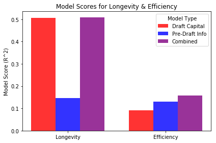

```python
# Data to plot
full_model = (full_longevity_score, full_efficiency_score)
DC_model = (DC_longevity_score, DC_efficiency_score)
EAC_model = (EAC_longevity_score, EAC_efficiency_score)
n_groups = 2

# Create plot
fig, ax = plt.subplots()
index = np.arange(n_groups)
bar_width = 0.25
opacity = 0.8

DC_bars = plt.bar(index, DC_model, bar_width,
                alpha=opacity, color="red", label="Draft Capital")
EAC_bars = plt.bar(index + bar_width, EAC_model, bar_width,
                alpha=opacity, color="blue", label = "Pre-Draft Info")
full_bars = plt.bar(index + bar_width*2, full_model, bar_width,
                alpha=opacity, color="purple", label="Combined")

plt.ylabel("Model Score (R^2)")
plt.title("Model Scores for Longevity & Efficiency")
plt.xticks(index + bar_width, ("Longevity","Efficiency"))
plt.legend(title="Model Type")

plt.tight_layout()
plt.show()
```

### Longevity

If you measure NFL success for quarterback prospects by longevity, my model based purely on Pre-Draft Info gets crushed by Draft Capital. At face value, it would seem like NFL teams are much better than me at identifying QBs who will last at the pro level.

Adding Pre-Draft Info to Draft Capital gives the slightest of increases, .506 R^2 to .510. Given the added complexity for such a slim gain, a model is not necessary. Draft Capital alone can be used to predict NFL longevity. While it still only explains half of the variance, that is no small feat for a prediction involving NFL players.

### Efficiency

The easiest takeaway to see here is that NFL efficiency for QB prospects can not be predicted nearly as well as longevity. We fall back into the 10%-20% range of variance explained that we see in the stability of QB efficiency metrics & predicting Draft Capital with college efficiency.

Here we see that my model based on Pre-Draft Info (namely college TANY/A*, age, and height) beats Draft Capital, my proxy for NFL team's evaluations. While they both are relatively low by general predictive analytics standards, my R^2 of .130 is 43% higher than the Draft Capital mark of .091.

If we add Draft Capital into my model, we bump the R^2 up to .158. Because of this, I believe that if I add in Projected Draft Capital based on consensus of NFL mock drafts or prospect rankings, I can beat NFL evaluations by even more.

I think it's fair to say Draft Capital struggles in predicting NFL efficiency compared to my model. This casts doubt on the above conclusion that NFL teams are much better than me at identifying QBs who can last at the pro level.

One possible explanation is that higher Draft Capital means a quarterback will be given a longer leash. I believe this to be true on some level, but it is tough to say how much that contributes to the correlation between Draft Capital and NFL longevity without further study.

Either way, I believe I have identified a small market inefficiency among quarterback draft prospects. Given the high correlation between passing efficiency and winning in the NFL, I believe it is in teams' best interests to weight college efficiency more than they have historically.